# Enrichment Analysis of H3K27ac peaks II

last changed: 2023-08-29

# Feature annotation of H3K27ac peaks

## Data processing

Load the `rlog` transformed DESeq data set and construct the required data frames. The function `assay` returns the values and `colData` returns the information about the experimental design.

```r
> rlog.heat <- readRDS(file = "./../Significance_testing/Data/rlog_H3K27ac_sig.rds")
> head(rlog.heat)
```

```
## class: DESeqTransform
## dim: 6 22
## metadata(1): version
## assays(1): ''
## rownames(6): chr1:923270-926516 chr1:1019193-1026163 ...
##   chr1:1693797-1694533 chr1:1777412-1779430
## rowData names(7): baseMean baseVar ... dispFit rlogIntercept
## colnames(22): U2OS31_T0h_Rep1 U2OS31_T0h_Rep2 ... U2OS33_T4h_Rep2
##   U2OS33_T4h_Rep3
## colData names(4): construct replica time sizeFactor
```

```r
> m.H3.ac <- assay(rlog.heat)
> head(m.H3.ac)
```

```
##                      U2OS31_T0h_Rep1 U2OS31_T0h_Rep2 U2OS31_T0h_Rep3
## chr1:923270-926516          7.999335        8.985719        8.334292
## chr1:1019193-1026163       10.176104       10.552625       10.176257
## chr1:1247714-1248873        6.056909        6.133303        6.087146
## chr1:1510763-1513097        8.158436        8.641024        8.316338
## chr1:1693797-1694533        5.855966        6.249061        6.254131
## chr1:1777412-1779430        8.254269        8.532619        8.194564
##                      U2OS31_T1h_Rep1 U2OS31_T1h_Rep2 U2OS31_T1h_Rep3
## chr1:923270-926516          8.984147        9.150024        8.944955
## chr1:1019193-1026163       10.195272       10.614003       10.396865
## chr1:1247714-1248873        5.670621        5.985477        6.047134
## chr1:1510763-1513097        8.001440        8.409950        8.117495
## chr1:1693797-1694533        5.980106        5.659072        5.717397
## chr1:1777412-1779430        8.288444        8.669121        8.251984
##                      U2OS31_T2h_Rep1 U2OS31_T2h_Rep2 U2OS31_T4h_Rep1
## chr1:923270-926516          8.595118        7.913353        8.339156
## chr1:1019193-1026163       10.253510       10.229117       10.107741
## chr1:1247714-1248873        6.025009        6.327132        6.310482
## chr1:1510763-1513097        8.125629        8.327780        8.154818
## chr1:1693797-1694533        5.686861        5.406716        5.496686
## chr1:1777412-1779430        8.239086        8.180811        8.219928
##                      U2OS31_T4h_Rep2 U2OS33_T0h_Rep1 U2OS33_T0h_Rep2
## chr1:923270-926516          7.703591        8.386781        9.347124
## chr1:1019193-1026163       10.050250       10.118744       10.234218
## chr1:1247714-1248873        6.309163        4.995534        4.703969
## chr1:1510763-1513097        8.348846        8.169646        8.498227
## chr1:1693797-1694533        5.570715        5.568621        5.670425
## chr1:1777412-1779430        8.079199        8.246655        8.609543
##                      U2OS33_T0h_Rep3 U2OS33_T1h_Rep1 U2OS33_T1h_Rep2
## chr1:923270-926516          8.631627        9.509342        9.565205
## chr1:1019193-1026163       10.053496       10.395578       10.713748
## chr1:1247714-1248873        5.473339        5.046691        5.117208
## chr1:1510763-1513097        8.056081        8.024688        8.347749
## chr1:1693797-1694533        6.074303        5.866331        5.491292
## chr1:1777412-1779430        8.057408        8.464051        8.869211
##                      U2OS33_T1h_Rep3 U2OS33_T2h_Rep1 U2OS33_T2h_Rep2
## chr1:923270-926516          8.963849        8.769139        8.500228
## chr1:1019193-1026163       10.183106       10.170189       10.067985
## chr1:1247714-1248873        5.168992        4.608407        5.152406
## chr1:1510763-1513097        8.150377        7.964385        8.405097
## chr1:1693797-1694533        5.430248        5.700828        4.943728
## chr1:1777412-1779430        8.296347        8.392284        8.438388
##                      U2OS33_T2h_Rep3 U2OS33_T4h_Rep1 U2OS33_T4h_Rep2
## chr1:923270-926516          8.292179        8.330028        8.059455
## chr1:1019193-1026163        9.812701        9.930633        9.988549
## chr1:1247714-1248873        5.111077        5.404046        5.591879
## chr1:1510763-1513097        8.100840        7.945059        8.204598
## chr1:1693797-1694533        5.203921        5.466183        5.355025
## chr1:1777412-1779430        8.008979        8.080821        8.430147
##                      U2OS33_T4h_Rep3
## chr1:923270-926516          8.103128
## chr1:1019193-1026163        9.748084
## chr1:1247714-1248873        5.471632
## chr1:1510763-1513097        7.902477
## chr1:1693797-1694533        5.242868
## chr1:1777412-1779430        7.985112
```

```r
> info.H3.ac <- data.frame(colData(rlog.heat))
> paged_table(info.H3.ac)
```

|  | construct | replica | time | sizeFactor |
| --- | --- | --- | --- | --- |
| U2OS31_T0h_Rep1 | U2OS31 | Rep1 | 0 | 0.9713745 |
| U2OS31_T0h_Rep2 | U2OS31 | Rep2 | 0 | 0.9677638 |
| U2OS31_T0h_Rep3 | U2OS31 | Rep3 | 0 | 1.4070125 |
| U2OS31_T1h_Rep1 | U2OS31 | Rep1 | 1 | 1.3427846 |
| U2OS31_T1h_Rep2 | U2OS31 | Rep2 | 1 | 1.3689437 |
| U2OS31_T1h_Rep3 | U2OS31 | Rep3 | 1 | 1.3748857 |
| U2OS31_T2h_Rep1 | U2OS31 | Rep1 | 2 | 0.9648885 |
| U2OS31_T2h_Rep2 | U2OS31 | Rep2 | 2 | 1.3894730 |
| U2OS31_T4h_Rep1 | U2OS31 | Rep1 | 4 | 1.0879097 |
| U2OS31_T4h_Rep2 | U2OS31 | Rep2 | 4 | 1.2114263 |

[output cut: 12 more lines]

Next the `GRanges` object can be constructed using the `rownames` of the DESeq data set, which contain information about the location of each peak.

```r
> chr <- str_split_i(rownames(m.H3.ac), ":", 1)
> pos <- str_split_i(rownames(m.H3.ac), ":", 2)
> start <- as.integer(str_split_i(pos, "-", 1))
> end <- as.integer(str_split_i(rownames(m.H3.ac), "-", 2))
>
> peaks.H3ac <- GRanges(seqnames = chr,
+                         ranges =IRanges(start = start, end = end))
> head(peaks.H3ac)
```

```
## GRanges object with 6 ranges and 0 metadata columns:
##       seqnames          ranges strand
##          <Rle>       <IRanges>  <Rle>
##   [1]     chr1   923270-926516      *
##   [2]     chr1 1019193-1026163      *
##   [3]     chr1 1247714-1248873      *
##   [4]     chr1 1510763-1513097      *
##   [5]     chr1 1693797-1694533      *
##   [6]     chr1 1777412-1779430      *
##   -------
##   seqinfo: 27 sequences from an unspecified genome; no seqlengths
```

```r
> saveRDS(peaks.H3ac, "./Data/peaks_H3ac.rds")
```

To visualize the distance to TSS the by cluster, a `list` containing a entry for  
each cluster with the corresponding peaks is required. Thus, the clustering results are loaded and used to filter the `GRanges` object.

```r
> kmeans.k4 <- readRDS("./../Clustering/Data/kmeans.rds")
> lapply(kmeans.k4, head)
```

```
## $cluster
##   chr1:923270-926516 chr1:1019193-1026163 chr1:1247714-1248873
##                    3                    3                    1
## chr1:1510763-1513097 chr1:1693797-1694533 chr1:1777412-1779430
##                    3                    2                    3
##
## $centers
##   U2OS31_T0h_Rep1 U2OS31_T0h_Rep2 U2OS31_T0h_Rep3 U2OS31_T1h_Rep1
## 1      -0.7989109      -0.6944340     -0.56203302      -0.6860864
## 2       0.9129257       0.5968878      0.63477375       0.5345909
## 3      -0.3049047       1.3308952      0.09915553       0.2630061
## 4       0.3551421      -0.9764487     -0.44783229      -0.2559633
##   U2OS31_T1h_Rep2 U2OS31_T1h_Rep3 U2OS31_T2h_Rep1 U2OS31_T2h_Rep2
## 1      0.06248088     0.007743843   -0.0006624378       1.1384911
## 2      0.03821704     0.179774101   -0.2686633007      -1.0227795
## 3      0.74279442     0.155319530    0.0373515560      -0.2786447
## 4     -0.67530196    -0.503676832    0.0640594770       0.2387747
##   U2OS31_T4h_Rep1 U2OS31_T4h_Rep2 U2OS33_T0h_Rep1 U2OS33_T0h_Rep2
## 1       0.4581072       1.0753038     -0.88471567      -0.8268561
## 2      -0.7228280      -0.8828984      1.05491537       0.6356034
## 3      -0.8692720      -1.1757009     -0.06490102       1.1657194
## 4       1.0496580       1.1515889      0.09968997      -0.9002604
##   U2OS33_T0h_Rep3 U2OS33_T1h_Rep1 U2OS33_T1h_Rep2 U2OS33_T1h_Rep3
## 1     -0.68991799      -0.8276500      -0.3549558      -0.2178705
## 2      0.80225985       0.6882109       0.3567607       0.3635360
## 3      0.04591291       0.7205913       1.2270104       0.2166212
## 4     -0.23669320      -0.5770721      -1.0322469      -0.4882836
##   U2OS33_T2h_Rep1 U2OS33_T2h_Rep2 U2OS33_T2h_Rep3 U2OS33_T4h_Rep1
## 1     -0.03691563       0.7689672       0.7425148       0.4244171
## 2     -0.13167470      -0.9152495      -0.7037874      -0.5662325
## 3      0.04953113       0.2023171      -0.4495951      -1.1267555
## 4     -0.01065372      -0.2273233       0.2606133       1.0715938
##   U2OS33_T4h_Rep2 U2OS33_T4h_Rep3
## 1       1.0339979       0.8689847
## 2      -0.9010046      -0.6833377
## 3      -0.6783144      -1.3081373
## 4       0.9214561       1.1191802
##
## $totss
## [1] 122540.7
##
## $withinss
## [1] 13400.98 14589.08 15344.94 13277.07
##
## $tot.withinss
## [1] 56612.06
##
## $betweenss
## [1] 65928.6
##
## $size
## [1] 1414 1485 1885 1387
##
## $iter
## [1] 2
##
## $ifault
## [1] 0
```

```r
> clus.kmeans <- melt(kmeans.k4$cluster)
> clus.kmeans <- cbind(clus.kmeans, 1:nrow(clus.kmeans))
> colnames(clus.kmeans) <- c("cluster", "ind")
> clus.kmeans <- clus.kmeans[order(clus.kmeans[, "cluster"]), ]
>
> paged_table(clus.kmeans)
```

|  | cluster | ind |
| --- | --- | --- |
| chr1:1247714-1248873 | 1 | 3 |
| chr1:6489342-6492512 | 1 | 14 |
| chr1:7249625-7251186 | 1 | 18 |
| chr1:7294178-7295015 | 1 | 19 |
| chr1:7296028-7304174 | 1 | 20 |
| chr1:8039827-8041487 | 1 | 24 |
| chr1:8044082-8048968 | 1 | 25 |
| chr1:8058748-8059997 | 1 | 26 |
| chr1:9299314-9304064 | 1 | 31 |
| chr1:9411854-9414465 | 1 | 32 |

[output cut: 6161 more lines]

```r
> ind.cluster1 <- clus.kmeans[which(clus.kmeans[, "cluster"] == 1), "ind"]
> ind.cluster2 <- clus.kmeans[which(clus.kmeans[, "cluster"] == 2), "ind"]
> ind.cluster3 <- clus.kmeans[which(clus.kmeans[, "cluster"] == 3), "ind"]
> ind.cluster4 <- clus.kmeans[which(clus.kmeans[, "cluster"] == 4), "ind"]
>
> peaks.k1 <- peaks.H3ac[ind.cluster1, ]
> peaks.k2 <- peaks.H3ac[ind.cluster2, ]
> peaks.k3 <- peaks.H3ac[ind.cluster3, ]
> peaks.k4 <- peaks.H3ac[ind.cluster4, ]
>
> peaks <- list(cluster_1 = peaks.k1, cluster_2 = peaks.k2,
+               cluster_3 = peaks.k3, cluster_4 = peaks.k4)
> lapply(peaks, head)
```

```
## $cluster_1
## GRanges object with 6 ranges and 0 metadata columns:
##       seqnames          ranges strand
##          <Rle>       <IRanges>  <Rle>
##   [1]     chr1 1247714-1248873      *
##   [2]     chr1 6489342-6492512      *
##   [3]     chr1 7249625-7251186      *
##   [4]     chr1 7294178-7295015      *
##   [5]     chr1 7296028-7304174      *
##   [6]     chr1 8039827-8041487      *
##   -------
##   seqinfo: 27 sequences from an unspecified genome; no seqlengths
##
## $cluster_2
## GRanges object with 6 ranges and 0 metadata columns:
##       seqnames          ranges strand
##          <Rle>       <IRanges>  <Rle>
##   [1]     chr1 1693797-1694533      *
##   [2]     chr1 3624157-3625723      *
##   [3]     chr1 3678537-3678916      *
##   [4]     chr1 7548713-7551013      *
##   [5]     chr1 8268601-8270043      *
##   [6]     chr1 9265794-9267308      *
##   -------
##   seqinfo: 27 sequences from an unspecified genome; no seqlengths
##
## $cluster_3
## GRanges object with 6 ranges and 0 metadata columns:
##       seqnames          ranges strand
##          <Rle>       <IRanges>  <Rle>
##   [1]     chr1   923270-926516      *
##   [2]     chr1 1019193-1026163      *
##   [3]     chr1 1510763-1513097      *
##   [4]     chr1 1777412-1779430      *
##   [5]     chr1 1889608-1892303      *
##   [6]     chr1 2226456-2230506      *
##   -------
##   seqinfo: 27 sequences from an unspecified genome; no seqlengths
##
## $cluster_4
## GRanges object with 6 ranges and 0 metadata columns:
##       seqnames            ranges strand
##          <Rle>         <IRanges>  <Rle>
##   [1]     chr1   7311995-7314407      *
##   [2]     chr1   8941172-8943832      *
##   [3]     chr1 10414942-10416287      *
##   [4]     chr1 14475937-14478853      *
##   [5]     chr1 14484916-14488449      *
##   [6]     chr1 17865163-17867445      *
##   -------
##   seqinfo: 27 sequences from an unspecified genome; no seqlengths
```

## Average distance to TSS

The `GRanges` list can then be used to plot the average distance to the TSS by cluster.

```r
> hg38 <- TxDb.Hsapiens.UCSC.hg38.knownGene
> promoter <- getPromoters(TxDb = hg38, upstream=3000, downstream=3000)
> tagM.peaks <- lapply(peaks, getTagMatrix, windows=promoter)
```

```
## >> preparing start_site regions by gene... 2023-08-29 11:13:50
## >> preparing tag matrix...  2023-08-29 11:13:50
## >> preparing start_site regions by gene... 2023-08-29 11:14:30
## >> preparing tag matrix...  2023-08-29 11:14:30
## >> preparing start_site regions by gene... 2023-08-29 11:15:06
## >> preparing tag matrix...  2023-08-29 11:15:06
## >> preparing start_site regions by gene... 2023-08-29 11:15:42
## >> preparing tag matrix...  2023-08-29 11:15:42
```

```
## >> plotting figure...             2023-08-29 11:16:15
```

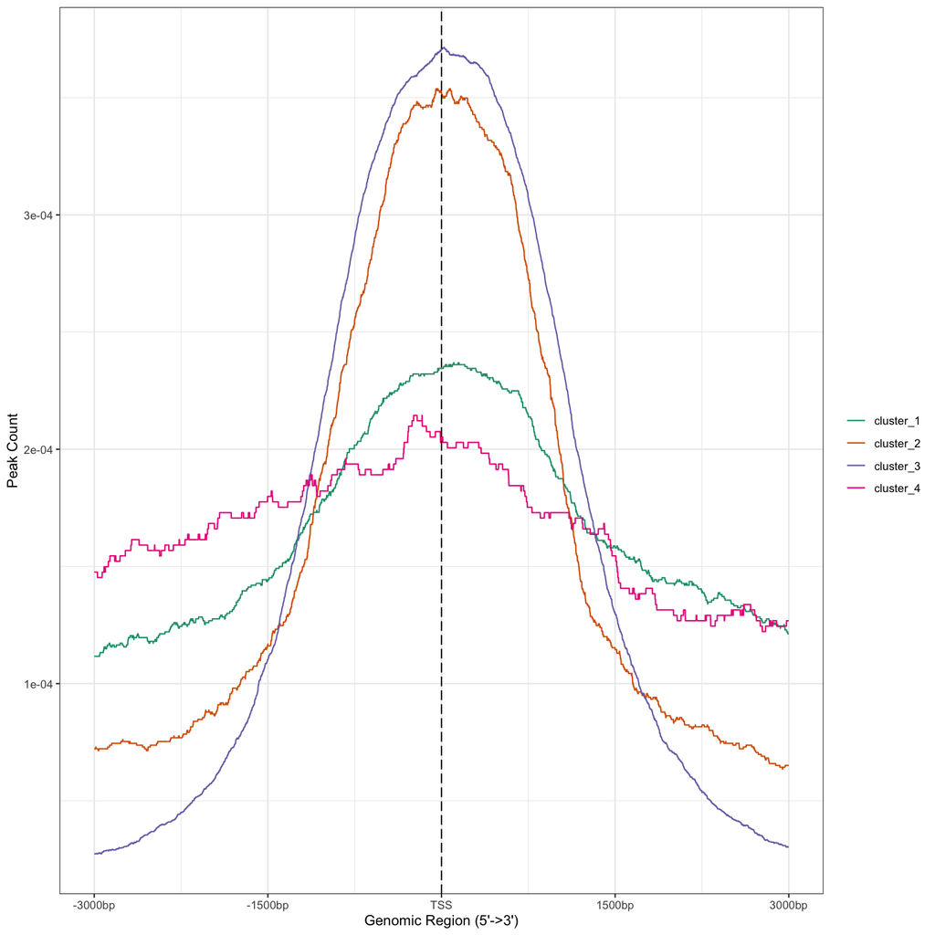

```r
> plotAvgProf(tagM.peaks, TxDb = hg38, xlim=c(-3000, 3000),
+              xlab = "Genomic Region (5'->3')", ylab = "Peak Count") +
+   scale_color_manual(values = brewer.pal(n = 4, name = "Dark2"))
```

## Feature annotation

Next, the peaks were annotated to genes using `annotatePeak` and all known human genes. The resulting object was then plotted with `plotAnnoBar`, to visualize the distribution of features among peaks.

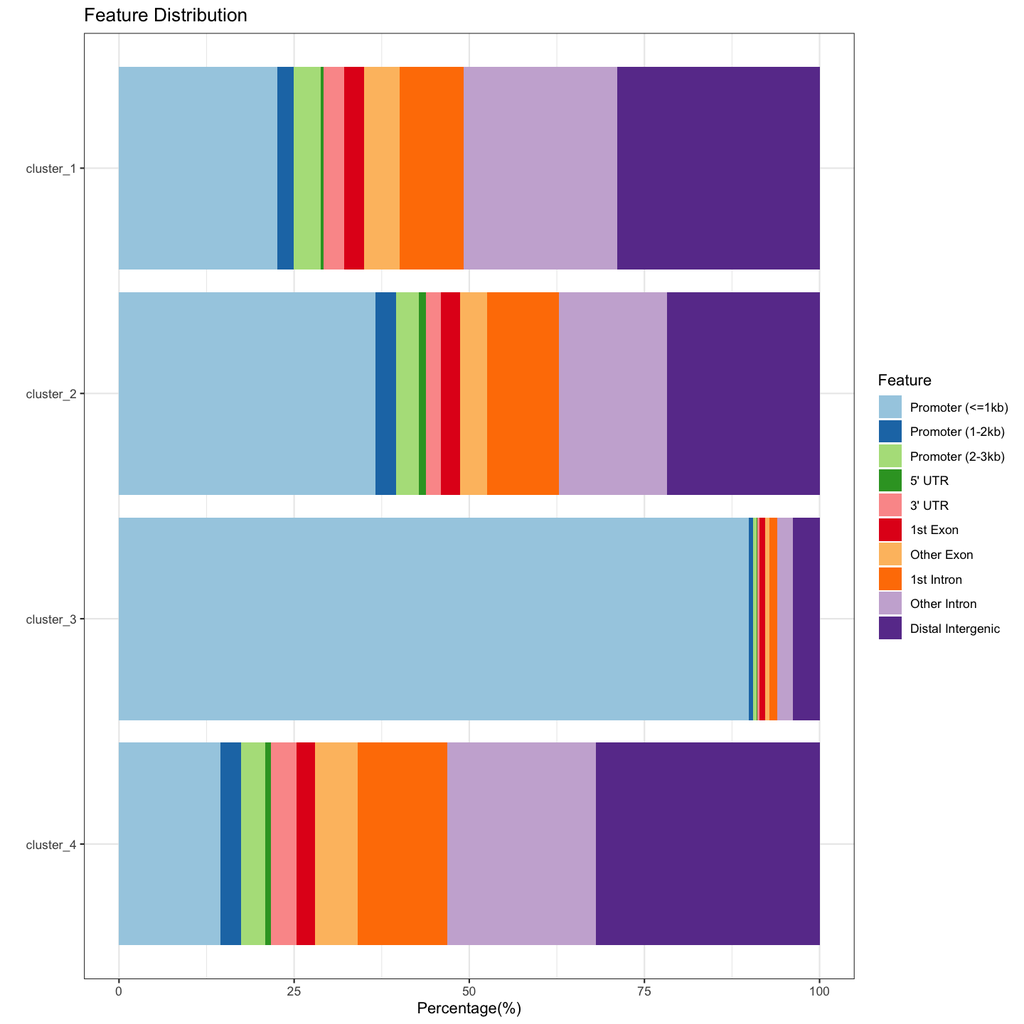

```r
> anno.list <- lapply(peaks, annotatePeak, TxDb = hg38,
+                          tssRegion=c(-3000, 3000), verbose=FALSE)
>
> plotAnnoBar(anno.list)
```

# Enrichment Analysis

## Data processing

For the enrichment analysis the peaks were annotated to only coding genes within a range of -1 to 1 kb from the transcription start site (TSS). For this the peaks are annotated to using only the protein coding genes.

```r
> TxDb.protein.coding <- loadDb( file="./Data/TxDb.protein.coding.sqlite")
> seqlevelsStyle(TxDb.protein.coding) <- "UCSC"
>
> peak.coding <- lapply(peaks, annotatePeak, TxDb = TxDb.protein.coding,
+                       tssRegion = c(-3000, 3000), verbose=FALSE)
```

Next, the following function was used to translate the ENSEMBL identifiers to ENTREZID.

```r
> # generate required structure:
> conv2table<-function(x){
+   eg = bitr(x@anno$geneId, fromType="ENSEMBL", toType="SYMBOL", OrgDb="org.Hs.eg.db")
+   ez = bitr(x@anno$geneId, fromType="ENSEMBL", toType="ENTREZID", OrgDb="org.Hs.eg.db")
+   anno.table<-x@anno
+   #add gene symbols
+   mx<-match(anno.table$geneId, eg$ENSEMBL)
+   anno.table$gene_symbol<-eg[mx,"SYMBOL"]
+   #add gene entrezID
+   mx<-match(anno.table$geneId, ez$ENSEMBL)
+   anno.table$gene_entrez<-ez[mx,"ENTREZID"]
+
+   res.table<-cbind(
+     chr=as.vector(seqnames(anno.table)),
+     start=start(anno.table),
+     end=end(anno.table),
+     name=anno.table$name,
+     peak.p_adj=anno.table$qValue,
+     strand=rep(".", length(anno.table)),
+     genome_anno=anno.table$annotation,
+     gene_symbol=anno.table$gene_symbol,
+     gene_entrez=anno.table$gene_entrez,
+     distanceToTSS=anno.table$distanceToTSS,
+     transcriptId=anno.table$transcriptId,
+     geneId_ensembl=anno.table$geneId)
+ }
>
> peak.coding.ID <- lapply(peak.coding, function(n) conv2table(n))
> lapply(peak.coding.ID, head)
```

```
## $cluster_1
##      chr    start     end       strand
## [1,] "chr1" "1247714" "1248873" "."
## [2,] "chr1" "6489342" "6492512" "."
## [3,] "chr1" "7249625" "7251186" "."
## [4,] "chr1" "7294178" "7295015" "."
## [5,] "chr1" "7296028" "7304174" "."
## [6,] "chr1" "8039827" "8041487" "."
##      genome_anno                                                gene_symbol
## [1,] "Promoter (<=1kb)"                                         "C1QTNF12"
## [2,] "Promoter (<=1kb)"                                         "PLEKHG5"
## [3,] "Exon (ENST00000303635/ENSG00000171735, exon 5 of 23)"     "CAMTA1"
## [4,] "Intron (ENST00000303635/ENSG00000171735, intron 5 of 22)" "CAMTA1"
## [5,] "Intron (ENST00000303635/ENSG00000171735, intron 5 of 22)" "CAMTA1"
## [6,] "Distal Intergenic"                                        "ERRFI1"
```

[output cut: 69 more lines]

The resulting list was then filtered for peaks which are within a range of -1 to 1 kb from the TSS.

```r
> peak.coding.1kb <- lapply(peak.coding.ID, function(x)
+   filter(as.data.frame(x),
+          abs(as.integer(as.data.frame(x)$distanceToTSS)) <= 1000))
>
> lapply(peak.coding.1kb, head)
```

```
## $cluster_1
##    chr    start      end strand      genome_anno gene_symbol gene_entrez
## 1 chr1  1247714  1248873      . Promoter (<=1kb)    C1QTNF12      388581
## 2 chr1  6489342  6492512      . Promoter (<=1kb)     PLEKHG5       57449
## 3 chr1 25549143 25550979      . Promoter (<=1kb)     LDLRAP1       26119
## 4 chr1 25888639 25896455      . Promoter (<=1kb)       STMN1        3925
## 5 chr1 26847932 26850786      . Promoter (<=1kb)     ZDHHC18       84243
## 6 chr1 27099056 27100613      . Promoter (<=1kb)      SLC9A1        6548
##   distanceToTSS    transcriptId  geneId_ensembl
## 1          -992 ENST00000330388 ENSG00000184163
## 2             0 ENST00000377725 ENSG00000171680
## 3             0 ENST00000485476 ENSG00000157978
## 4             0 ENST00000513116 ENSG00000117632
## 5             0 ENST00000488397 ENSG00000204160
## 6             0 ENST00000490329 ENSG00000090020
```

[output cut: 48 more lines]

```r
> saveRDS(peak.coding.1kb, file = "./Data/peaks_H3ac_cod1kb.rds")
>
> names(peak.coding.1kb) <- c("1", "2", "3", "4")
> cod.genes.1kb <- lapply(peak.coding.1kb, function(i) as.data.frame(i)$gene_entrez)
```

## Reactome pathway analysis enrichment analysis

Finally, the filtered list with the coding genes can be used for an enrichment analysis using the function `enrichPathway`, which can be plotted using `dotplot`.

```r
> comp.Reac <- compareCluster(geneCluster = cod.genes.1kb,
+                             fun = "enrichPathway",
+                             pvalueCutoff = 0.05,
+                             pAdjustMethod = "BH")
>
> comp.Reac %>% as.data.frame() %>% paged_table()
```

| Cluster | ID | Description | GeneRatio | BgRatio | pvalue | p.adjust | qvalue | geneID | Count |
| --- | --- | --- | --- | --- | --- | --- | --- | --- | --- |
| 1 | R-HSA-9633012 | Response of EIF2AK4 (GCN2) to amino acid deficiency | 17/167 | 102/10955 | 1.787066e-13 | 1.505866e-10 | 1.281439e-10 | 6157/6231/10985/6235/6210/55364/6142/23521/6233/6168/3921/200916/6167/6228/4736/6206/6156 | 17 |
| 1 | R-HSA-156902 | Peptide chain elongation | 16/167 | 90/10955 | 3.335252e-13 | 1.505866e-10 | 1.281439e-10 | 6157/6231/6235/6210/6142/23521/6233/6168/3921/200916/6167/6228/4736/1915/6206/6156 | 16 |
| 1 | R-HSA-156842 | Eukaryotic Translation Elongation | 16/167 | 94/10955 | 6.765906e-13 | 2.036538e-10 | 1.733022e-10 | 6157/6231/6235/6210/6142/23521/6233/6168/3921/200916/6167/6228/4736/1915/6206/6156 | 16 |
| 1 | R-HSA-192823 | Viral mRNA Translation | 15/167 | 90/10955 | 5.042628e-12 | 1.138373e-09 | 9.687154e-10 | 6157/6231/6235/6210/6142/23521/6233/6168/3921/200916/6167/6228/4736/6206/6156 | 15 |
| 1 | R-HSA-2408557 | Selenocysteine synthesis | 15/167 | 94/10955 | 9.710470e-12 | 1.461426e-09 | 1.243622e-09 | 6157/6231/6235/6210/6142/23521/6233/6168/3921/200916/6167/6228/4736/6206/6156 | 15 |
| 1 | R-HSA-72764 | Eukaryotic Translation Termination | 15/167 | 94/10955 | 9.710470e-12 | 1.461426e-09 | 1.243622e-09 | 6157/6231/6235/6210/6142/23521/6233/6168/3921/200916/6167/6228/4736/6206/6156 | 15 |
| 1 | R-HSA-1799339 | SRP-dependent cotranslational protein targeting to membrane | 16/167 | 113/10955 | 1.273784e-11 | 1.502594e-09 | 1.278654e-09 | 6157/6231/6235/6210/6142/23521/6233/6168/3921/200916/6167/6228/6745/4736/6206/6156 | 16 |
| 1 | R-HSA-975956 | Nonsense Mediated Decay (NMD) independent of the Exon Junction Complex (EJC) | 15/167 | 96/10955 | 1.331201e-11 | 1.502594e-09 | 1.278654e-09 | 6157/6231/6235/6210/6142/23521/6233/6168/3921/200916/6167/6228/4736/6206/6156 | 15 |
| 1 | R-HSA-927802 | Nonsense-Mediated Decay (NMD) | 16/167 | 116/10955 | 1.919531e-11 | 1.733336e-09 | 1.475008e-09 | 6157/55110/6231/6235/6210/6142/23521/6233/6168/3921/200916/6167/6228/4736/6206/6156 | 16 |
| 1 | R-HSA-975957 | Nonsense Mediated Decay (NMD) enhanced by the Exon Junction Complex (EJC) | 16/167 | 116/10955 | 1.919531e-11 | 1.733336e-09 | 1.475008e-09 | 6157/55110/6231/6235/6210/6142/23521/6233/6168/3921/200916/6167/6228/4736/6206/6156 | 16 |

[output cut: 253 more lines]

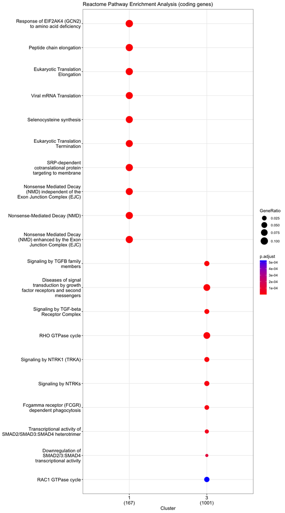

```r
> dotplot(comp.Reac, showCategory = 10,
+         title = "Reactome Pathway Enrichment Analysis (coding genes)")
```

## Gene Ontology enrichment analysis

Exactly the same as above can be done with the function `enrichGO`.

```r
> comp.GO <- compareCluster(geneCluster = cod.genes.1kb,
+                           fun = "enrichGO",
+                           OrgDb = org.Hs.eg.db,
+                           ont = "BP",
+                           readable = T,
+                           pvalueCutoff = 0.05,
+                           pAdjustMethod = "BH")
>
> comp.GO %>% as.data.frame() %>% paged_table()
```

| Cluster | ID | Description | GeneRatio | BgRatio | pvalue | p.adjust | qvalue | geneID | Count |
| --- | --- | --- | --- | --- | --- | --- | --- | --- | --- |
| 1 | GO:0002181 | cytoplasmic translation | 16/227 | 159/18614 | 1.102339e-10 | 3.887950e-07 | 3.317460e-07 | DPH5/RPL27A/RPS26/RPS29/RPS15A/RPL18A/RPL13A/RPS27A/RPL37A/RPSA/RPL22L1/RPL37/RPS23/RPL10A/RPS12/RPL30 | 16 |
| 1 | GO:0043254 | regulation of protein-containing complex assembly | 17/227 | 409/18614 | 1.185549e-05 | 1.779043e-02 | 1.517999e-02 | STMN1/IKBKE/NUMA1/STXBP6/STX1B/IMPACT/BAX/RPL13A/MAPRE3/CAPG/PFN2/ISL1/DAAM2/NRG1/CDK5RAP2/TRAF2/BTK | 17 |
| 1 | GO:0032967 | positive regulation of collagen biosynthetic process | 5/227 | 27/18614 | 1.673887e-05 | 1.779043e-02 | 1.517999e-02 | CREB3L1/BMP4/TGFB3/RUNX1/INHBA | 5 |
| 1 | GO:0010714 | positive regulation of collagen metabolic process | 5/227 | 28/18614 | 2.017627e-05 | 1.779043e-02 | 1.517999e-02 | CREB3L1/BMP4/TGFB3/RUNX1/INHBA | 5 |
| 1 | GO:0035051 | cardiocyte differentiation | 10/227 | 161/18614 | 2.908641e-05 | 1.958897e-02 | 1.671462e-02 | SLC9A1/TGFB2/NEBL/BMP4/CALR/FOXP1/PITX2/ISL1/INHBA/NRG1 | 10 |
| 1 | GO:0032964 | collagen biosynthetic process | 6/227 | 51/18614 | 3.506191e-05 | 1.958897e-02 | 1.671462e-02 | CREB3L1/SERPINH1/BMP4/TGFB3/RUNX1/INHBA | 6 |
| 1 | GO:0043410 | positive regulation of MAPK cascade | 18/227 | 495/18614 | 3.887802e-05 | 1.958897e-02 | 1.671462e-02 | GADD45A/TGFB2/DENND2B/GAS6/BMP4/TGFB3/TRAF7/CX3CL1/KSR1/CCL2/IGFBP4/EPHA4/ARL6IP5/INHBA/IGFBP3/NRG1/RB1CC1/TRAF2 | 18 |
| 1 | GO:0045445 | myoblast differentiation | 8/227 | 110/18614 | 6.091513e-05 | 2.685596e-02 | 2.291531e-02 | BCL9/TCF7L2/BMP4/ZFP36L1/ISL1/IGFBP3/NRG1/SMARCA2 | 8 |
| 2 | GO:0090066 | regulation of anatomical structure size | 29/450 | 492/18614 | 1.021759e-05 | 2.453074e-02 | 2.348575e-02 | HTR1D/MACF1/NGF/PIK3C2A/SPTBN2/GCH1/MMP2/TRPV2/SSH2/ACE/NHERF1/BAIAP2/PTPRS/VAV1/LRRC8E/KLF2/VASP/MYADM/ADD2/BIN1/ARPC2/CCDC51/CDHR2/PPARD/SRF/AQP1/BAIAP2L1/CYRIB/GBA2 | 29 |
| 2 | GO:0034329 | cell junction assembly | 27/450 | 444/18614 | 1.186780e-05 | 2.453074e-02 | 2.348575e-02 | CLSTN1/MACF1/FRMPD2/SPTBN2/CHD4/ACTN1/TAOK2/CDH5/ACE/ITGB4/ACTG1/CDH20/PTPRS/CAMSAP3/ADD2/ARVCF/PPM1F/PDLIM5/CTNND2/MEF2C/SRF/AFDN/DLC1/IKBKB/PTK2/PTPRD/CLDN2 | 27 |

[output cut: 344 more lines]

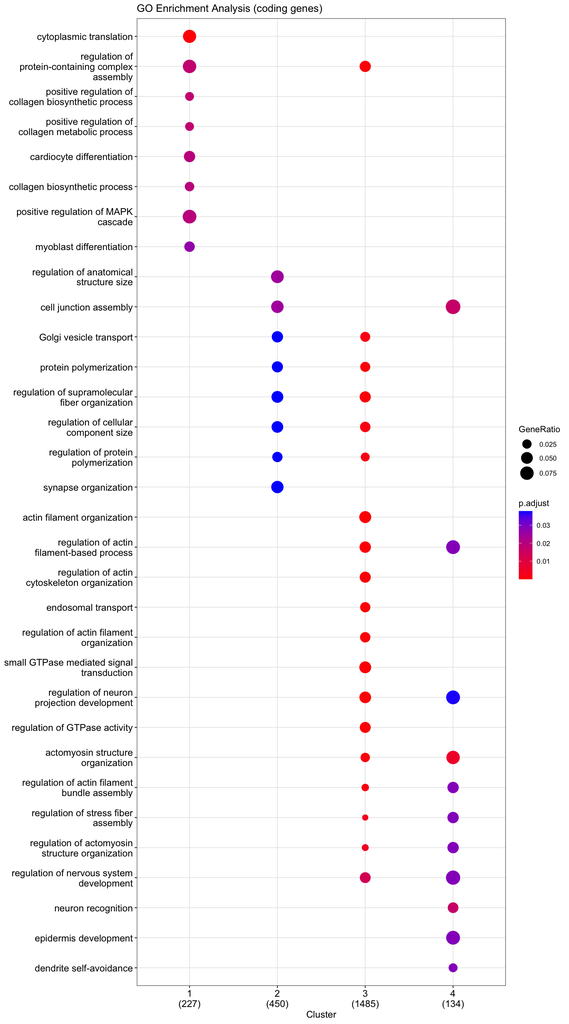

```r
> dotplot(comp.GO, showCategory = 10,
+         title = "GO Enrichment Analysis (coding genes)")
```

## References - packages

- Ahlmann-Eltze C, Hickey P, Pagès H (2023). *MatrixGenerics: S4 Generic Summary Statistic Functions that Operate on Matrix-Like Objects*. doi:10.18129/B9.bioc.MatrixGenerics https://doi.org/10.18129/B9.bioc.MatrixGenerics, R package version 1.12.2, https://bioconductor.org/packages/MatrixGenerics.
- Allaire J, Xie Y, Dervieux C, McPherson J, Luraschi J, Ushey K, Atkins A, Wickham H, Cheng J, Chang W, Iannone R (2023). *rmarkdown: Dynamic Documents for R*. R package version 2.23, https://github.com/rstudio/rmarkdown. Xie Y, Allaire J, Grolemund G (2018). *R Markdown: The Definitive Guide*. Chapman and Hall/CRC, Boca Raton, Florida. ISBN 9781138359338, https://bookdown.org/yihui/rmarkdown. Xie Y, Dervieux C, Riederer E (2020). *R Markdown Cookbook*. Chapman and Hall/CRC, Boca Raton, Florida. ISBN 9780367563837, https://bookdown.org/yihui/rmarkdown-cookbook.
- Arora S, Morgan M, Carlson M, Pagès H (2023). *GenomeInfoDb: Utilities for manipulating chromosome names, including modifying them to follow a particular naming style*. doi:10.18129/B9.bioc.GenomeInfoDb https://doi.org/10.18129/B9.bioc.GenomeInfoDb, R package version 1.36.0, https://bioconductor.org/packages/GenomeInfoDb.
- Bengtsson H (2023). *matrixStats: Functions that Apply to Rows and Columns of Matrices (and to Vectors)*. R package version 1.0.0, https://CRAN.R-project.org/package=matrixStats.
- Carlson M (2023). *org.Hs.eg.db: Genome wide annotation for Human*. R package version 3.17.0.
- Huber W, Carey VJ, Gentleman R, Anders S, Carlson M, Carvalho BS, Bravo HC, Davis S, Gatto L, Girke T, Gottardo R, Hahne F, Hansen KD, Irizarry RA, Lawrence M, Love MI, MacDonald J, Obenchain V, Ole’s AK, Pag`es H, Reyes A, Shannon P, Smyth GK, Tenenbaum D, Waldron L, Morgan M (2015). “Orchestrating high-throughput genomic analysis with Bioconductor.” *Nature Methods*, *12*(2), 115-121. http://www.nature.com/nmeth/journal/v12/n2/full/nmeth.3252.html.
- Huber, W., Carey, J. V, Gentleman, R., Anders, S., Carlson, M., Carvalho, S. B, Bravo, C. H, Davis, S., Gatto, L., Girke, T., Gottardo, R., Hahne, F., Hansen, D. K, Irizarry, A. R, Lawrence, M., Love, I. M, MacDonald, J., Obenchain, V., Ole’s, K. A, Pag`es, H., Reyes, A., Shannon, P., Smyth, K. G, Tenenbaum, D., Waldron, L., Morgan, M. (2015). “Orchestrating high-throughput genomic analysis with Bioconductor.” *Nature Methods*, *12*(2), 115-121. http://www.nature.com/nmeth/journal/v12/n2/full/nmeth.3252.html.
- Lawrence M, Huber W, Pagès H, Aboyoun P, Carlson M, Gentleman R, Morgan M, Carey V (2013). “Software for Computing and Annotating Genomic Ranges.” *PLoS Computational Biology*, *9*. doi:10.1371/journal.pcbi.1003118 https://doi.org/10.1371/journal.pcbi.1003118, http://www.ploscompbiol.org/article/info%3Adoi%2F10.1371%2Fjournal.pcbi.1003118.
- Lawrence M, Huber W, Pagès H, Aboyoun P, Carlson M, Gentleman R, Morgan M, Carey V (2013). “Software for Computing and Annotating Genomic Ranges.” *PLoS Computational Biology*, *9*. doi:10.1371/journal.pcbi.1003118 https://doi.org/10.1371/journal.pcbi.1003118, http://www.ploscompbiol.org/article/info%3Adoi%2F10.1371%2Fjournal.pcbi.1003118.
- Lawrence M, Huber W, Pagès H, Aboyoun P, Carlson M, Gentleman R, Morgan M, Carey V (2013). “Software for Computing and Annotating Genomic Ranges.” *PLoS Computational Biology*, *9*. doi:10.1371/journal.pcbi.1003118 https://doi.org/10.1371/journal.pcbi.1003118, http://www.ploscompbiol.org/article/info%3Adoi%2F10.1371%2Fjournal.pcbi.1003118.
- Love MI, Huber W, Anders S (2014). “Moderated estimation of fold change and dispersion for RNA-seq data with DESeq2.” *Genome Biology*, *15*, 550. doi:10.1186/s13059-014-0550-8 https://doi.org/10.1186/s13059-014-0550-8.
- Makowski D, Lüdecke D, Patil I, Thériault R, Ben-Shachar M, Wiernik B (2023). “Automated Results Reporting as a Practical Tool to Improve Reproducibility and Methodological Best Practices Adoption.” *CRAN*. https://easystats.github.io/report/.
- Morgan M, Obenchain V, Hester J, Pagès H (2023). *SummarizedExperiment: SummarizedExperiment container*. doi:10.18129/B9.bioc.SummarizedExperiment https://doi.org/10.18129/B9.bioc.SummarizedExperiment, R package version 1.30.2, https://bioconductor.org/packages/SummarizedExperiment.
- Neuwirth E (2022). *RColorBrewer: ColorBrewer Palettes*. R package version 1.1-3, https://CRAN.R-project.org/package=RColorBrewer.
- Pagès H, Carlson M, Falcon S, Li N (2023). *AnnotationDbi: Manipulation of SQLite-based annotations in Bioconductor*. doi:10.18129/B9.bioc.AnnotationDbi https://doi.org/10.18129/B9.bioc.AnnotationDbi, R package version 1.62.1, https://bioconductor.org/packages/AnnotationDbi.
- Pagès H, Lawrence M, Aboyoun P (2023). *S4Vectors: Foundation of vector-like and list-like containers in Bioconductor*. doi:10.18129/B9.bioc.S4Vectors https://doi.org/10.18129/B9.bioc.S4Vectors, R package version 0.38.1, https://bioconductor.org/packages/S4Vectors.
- R Core Team (2023). *R: A Language and Environment for Statistical Computing*. R Foundation for Statistical Computing, Vienna, Austria. https://www.R-project.org/.
- Team BC, Maintainer BP (2023). *TxDb.Hsapiens.UCSC.hg38.knownGene: Annotation package for TxDb object(s)*. R package version 3.17.0.
- Wang Q, Li M, Wu T, Zhan L, Li L, Chen M, Xie W, Xie Z, Hu E, Xu S, Yu G (2022). “Exploring epigenomic datasets by ChIPseeker.” *Current Protocols*, *2*(10), e585. doi:10.1002/cpz1.585 https://doi.org/10.1002/cpz1.585, https://onlinelibrary.wiley.com/share/author/GYJGUBYCTRMYJFN2JFZZ?target=10.1002/cpz1.585. Yu G, Wang L, He Q (2015). “ChIPseeker: an R/Bioconductor package for ChIP peak annotation, comparison and visualization.” *Bioinformatics*, *31*(14), 2382-2383. doi:10.1093/bioinformatics/btv145 https://doi.org/10.1093/bioinformatics/btv145.
- Wickham H (2007). “Reshaping Data with the reshape Package.” *Journal of Statistical Software*, *21*(12), 1-20. http://www.jstatsoft.org/v21/i12/.
- Wickham H (2016). *ggplot2: Elegant Graphics for Data Analysis*. Springer-Verlag New York. ISBN 978-3-319-24277-4, https://ggplot2.tidyverse.org.
- Wickham H (2022). *stringr: Simple, Consistent Wrappers for Common String Operations*. R package version 1.5.0, https://CRAN.R-project.org/package=stringr.
- Wickham H, François R, Henry L, Müller K, Vaughan D (2023). *dplyr: A Grammar of Data Manipulation*. R package version 1.1.2, https://CRAN.R-project.org/package=dplyr.
- Wu T, Hu E, Xu S, Chen M, Guo P, Dai Z, Feng T, Zhou L, Tang W, Zhan L, Fu x, Liu S, Bo X, Yu G (2021). “clusterProfiler 4.0: A universal enrichment tool for interpreting omics data.” *The Innovation*, *2*(3), 100141. doi:10.1016/j.xinn.2021.100141 https://doi.org/10.1016/j.xinn.2021.100141. Yu G, Wang L, Han Y, He Q (2012). “clusterProfiler: an R package for comparing biological themes among gene clusters.” *OMICS: A Journal of Integrative Biology*, *16*(5), 284-287. doi:10.1089/omi.2011.0118 https://doi.org/10.1089/omi.2011.0118.
- Xie Y (2023). *knitr: A General-Purpose Package for Dynamic Report Generation in R*. R package version 1.43, https://yihui.org/knitr/. Xie Y (2015). *Dynamic Documents with R and knitr*, 2nd edition. Chapman and Hall/CRC, Boca Raton, Florida. ISBN 978-1498716963, https://yihui.org/knitr/. Xie Y (2014). “knitr: A Comprehensive Tool for Reproducible Research in R.” In Stodden V, Leisch F, Peng RD (eds.), *Implementing Reproducible Computational Research*. Chapman and Hall/CRC. ISBN 978-1466561595.
- Yu G, He Q (2016). “ReactomePA: an R/Bioconductor package for reactome pathway analysis and visualization.” *Molecular BioSystems*, *12*(12), 477-479. doi:10.1039/C5MB00663E https://doi.org/10.1039/C5MB00663E, http://pubs.rsc.org/en/Content/ArticleLanding/2015/MB/C5MB00663E.

## Session Information

The following versions of R and R packages were used to generate the report above: